# capstonestats - Copy

Descriptive statistics of numerical data

```python
import pandas as pd
import numpy as np
import seaborn as sns
import matplotlib.pyplot as plt
%matplotlib inline
#displaying within notebook like plt.show
```

```python
car_sales = pd.read_csv('Car_sales_details_p3.csv')
sales_status = pd.read_csv('sales_Status_p3.csv')
state_region_mapping =pd.read_csv('State_region_mapping_p3.csv')
```

```python
merger1=pd.merge(car_sales,sales_status,on='Sales_ID',how='inner')
merger1.head()
```

|  | Sales_ID | name | year | selling_price | km_driven | State or Province | City | fuel | seller_type | transmission | owner | mileage | engine | max_power | seats | sold |
| --- | --- | --- | --- | --- | --- | --- | --- | --- | --- | --- | --- | --- | --- | --- | --- | --- |
| 0 | 1 | Maruti Swift Dzire VDI | 2014 | 450000 | 145500 | District of Columbia | Washington | Diesel | Individual | Manual | First Owner | 23.4 kmpl | 1248 CC | 74 bhp | 5 | Y |
| 1 | 2 | Skoda Rapid 1.5 TDI Ambition | 2014 | 370000 | 120000 | New York | New York City | Diesel | Individual | Manual | Second Owner | 21.14 kmpl | 1498 CC | 103.52 bhp | 5 | Y |
| 2 | 3 | Honda City 2017-2020 EXi | 2006 | 158000 | 140000 | Illinois | Chicago | Petrol | Individual | Manual | Third Owner | 17.7 kmpl | 1497 CC | 78 bhp | 5 | Y |
| 3 | 4 | Hyundai i20 Sportz Diesel | 2010 | 225000 | 127000 | Illinois | Chicago | Diesel | Individual | Manual | First Owner | 23.0 kmpl | 1396 CC | 90 bhp | 5 | Y |
| 4 | 5 | Maruti Swift VXI BSIII | 2007 | 130000 | 120000 | New York | New York City | Petrol | Individual | Manual | First Owner | 16.1 kmpl | 1298 CC | 88.2 bhp | 5 | Y |

```python
car_sales.mean()
```

```
Sales_ID           4070.106248
year               2013.983936
selling_price    649813.720845
km_driven         69188.659752
seats                 5.416393
dtype: float64
```

```python
car_dataset = pd.merge(merger1,state_region_mapping,on='State or Province',how='inner')
car_dataset.head()
```

|  | Sales_ID | name | year | selling_price | km_driven | State or Province | City | fuel | seller_type | transmission | owner | mileage | engine | max_power | seats | sold | Region |
| --- | --- | --- | --- | --- | --- | --- | --- | --- | --- | --- | --- | --- | --- | --- | --- | --- | --- |
| 0 | 1 | Maruti Swift Dzire VDI | 2014 | 450000 | 145500 | District of Columbia | Washington | Diesel | Individual | Manual | First Owner | 23.4 kmpl | 1248 CC | 74 bhp | 5 | Y | East |
| 1 | 38 | Hyundai Verna VTVT 1.6 SX Option | 2019 | 1149000 | 5000 | District of Columbia | Washington | Petrol | Individual | Manual | First Owner | 17.0 kmpl | 1591 CC | 121.3 bhp | 5 | Y | East |
| 2 | 66 | Ford Figo 1.2P Titanium MT | 2017 | 600000 | 25000 | District of Columbia | Washington | Petrol | Individual | Manual | Third Owner | 18.16 kmpl | 1196 CC | 86.8 bhp | 5 | Y | East |
| 3 | 68 | Volkswagen Ameo 1.5 TDI Highline 16 Alloy | 2016 | 540000 | 40000 | District of Columbia | Washington | Diesel | Individual | Manual | First Owner | 22.0 kmpl | 1498 CC | 108.495 bhp | 5 | Y | East |
| 4 | 69 | Honda City i DTEC VX | 2015 | 630000 | 135000 | District of Columbia | Washington | Diesel | Individual | Manual | First Owner | 25.1 kmpl | 1498 CC | 98.6 bhp | 5 | Y | East |

```python
car_dataset.mean()
```

```
Sales_ID           4070.106248
year               2013.983936
selling_price    649813.720845
km_driven         69188.659752
seats                 5.416393
dtype: float64
```

```python
car_dataset.median()
```

```
Sales_ID           4076.5
year               2015.0
selling_price    450000.0
km_driven         60000.0
seats                 5.0
dtype: float64
```

```python
car_dataset.std()
```

```
Sales_ID           2345.770159
year                  3.863695
selling_price    813582.748354
km_driven         56792.296343
seats                 0.959208
dtype: float64
```

```python
car_dataset.var()
```

```
Sales_ID         5.502638e+06
year             1.492814e+01
selling_price    6.619169e+11
km_driven        3.225365e+09
seats            9.200804e-01
dtype: float64
```

```python
car_dataset.mode()
```

|  | Sales_ID | name | year | selling_price | km_driven | State or Province | City | fuel | seller_type | transmission | owner | mileage | engine | max_power | seats | sold | Region |
| --- | --- | --- | --- | --- | --- | --- | --- | --- | --- | --- | --- | --- | --- | --- | --- | --- | --- |
| 0 | 1 | Maruti Swift Dzire VDI | 2017.0 | 300000.0 | 120000.0 | California | New York City | Diesel | Individual | Manual | First Owner | 18.9 kmpl | 1248 CC | 74 bhp | 5.0 | N | Central |
| 1 | 2 | NaN | NaN | NaN | NaN | NaN | NaN | NaN | NaN | NaN | NaN | NaN | NaN | NaN | NaN | NaN | NaN |
| 2 | 3 | NaN | NaN | NaN | NaN | NaN | NaN | NaN | NaN | NaN | NaN | NaN | NaN | NaN | NaN | NaN | NaN |
| 3 | 4 | NaN | NaN | NaN | NaN | NaN | NaN | NaN | NaN | NaN | NaN | NaN | NaN | NaN | NaN | NaN | NaN |
| 4 | 5 | NaN | NaN | NaN | NaN | NaN | NaN | NaN | NaN | NaN | NaN | NaN | NaN | NaN | NaN | NaN | NaN |
| ... | ... | ... | ... | ... | ... | ... | ... | ... | ... | ... | ... | ... | ... | ... | ... | ... | ... |
| 7901 | 8124 | NaN | NaN | NaN | NaN | NaN | NaN | NaN | NaN | NaN | NaN | NaN | NaN | NaN | NaN | NaN | NaN |
| 7902 | 8125 | NaN | NaN | NaN | NaN | NaN | NaN | NaN | NaN | NaN | NaN | NaN | NaN | NaN | NaN | NaN | NaN |
| 7903 | 8126 | NaN | NaN | NaN | NaN | NaN | NaN | NaN | NaN | NaN | NaN | NaN | NaN | NaN | NaN | NaN | NaN |
| 7904 | 8127 | NaN | NaN | NaN | NaN | NaN | NaN | NaN | NaN | NaN | NaN | NaN | NaN | NaN | NaN | NaN | NaN |
| 7905 | 8128 | NaN | NaN | NaN | NaN | NaN | NaN | NaN | NaN | NaN | NaN | NaN | NaN | NaN | NaN | NaN | NaN |

7906 rows × 17 columns

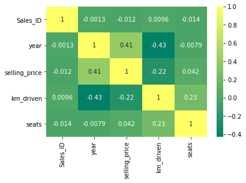

```python
import seaborn as sns
sns.heatmap(car_dataset.corr(),annot=True,cmap='summer')
```

Descriptive statistics of categorical data

COUNT PLOT

The following counts display how dataset is distributed among those categorical variables

[output not shown]

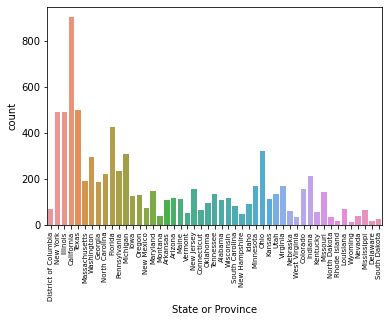

```python
ax=sns.countplot(car_dataset["State or Province"])
ax.set_xticklabels(ax.get_xticklabels(),rotation=90,fontsize = 7)
```

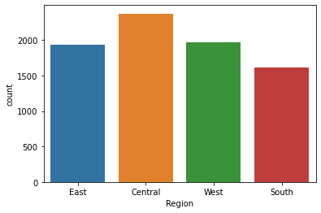

```python
sns.countplot(car_dataset["Region"])
```

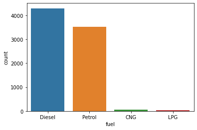

```python
sns.countplot(car_dataset["fuel"])
```

[figure not shown]

```python
sns.countplot(car_dataset["seller_type"])
```

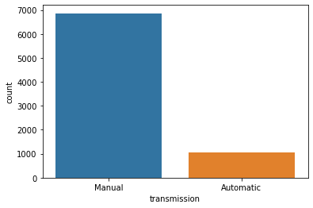

```python
sns.countplot(car_dataset["transmission"])
```

[output not shown]

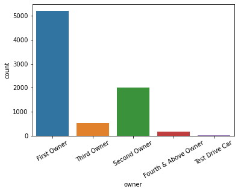

```python
ax=sns.countplot(car_dataset["owner"])
ax.set_xticklabels(ax.get_xticklabels(),rotation=30)
```

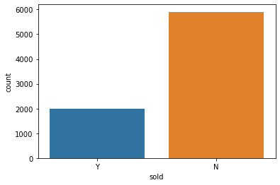

```python
sns.countplot(car_dataset["sold"])
```

DONUT CHART

[figure not shown]

```python
labels = ['Y', 'N']
plt.figure(figsize=(10,8))
plt.pie(car_dataset["sold"].value_counts(), labels=labels, wedgeprops={'width':0.3}, startangle=90, autopct='%1.1f%%')
plt.title("Sold %")
plt.show()
```

PAIR PLOT

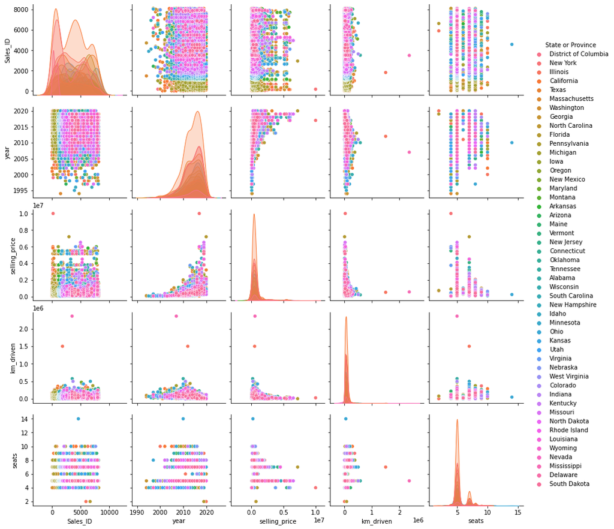

```python
sns.pairplot(car_dataset, hue='State or Province')
```

The distribution of state or province with respect to numerical data

HYPOTHESIS TESTING

One sample t test

Considering first 3950 selling prices of the data set as sample (half of dataset)

```python
mean_selling_price = car_dataset['selling_price'].mean()
mean_selling_price
```

```
649813.720844928
```

```python
from scipy.stats import ttest_1samp
tstat, pval = ttest_1samp(car_dataset["selling_price"][1:3950], mean_selling_price)
pval
```

```
0.6200425011685295
```

As the p value is greater than 0.05 the null hypothesis is failed to be rejected and the mean value of sample is same as population

Considering first 3950 km driven of the data set as sample (half of dataset)

```python
mean_km_driven = car_dataset['km_driven'].mean()
mean_km_driven
```

```
69188.65975208703
```

```python
from scipy.stats import ttest_1samp
tstat, pval = ttest_1samp(car_dataset["km_driven"][1:3950], mean_km_driven)
pval
```

```
0.6481316142627489
```

As the p value is greater than 0.05 the null hypothesis is failed to be rejected and the mean value of sample is same as population

Two sample t-test

Considering 3950 selling prices of the data set as two sample

```python
mean_1 = car_dataset['selling_price'][1:3950].mean()
mean_1
```

```
656390.1218029881
```

```python
mean_2 =car_dataset['selling_price'][3950:].mean()
mean_2
```

```
643299.4656218402
```

```python
from scipy.stats import ttest_ind
tstat, pval = ttest_ind(car_dataset['selling_price'][1:3950],car_dataset['selling_price'][3950:])
print("p-value",pval)
```

```
p-value 0.47449264084160103
```

As p-val is greater than 0.05 we fail to reject the null hypothesis and samples are related with each other

Considering 3950 km driven of the data set as two samples

```python
mean_km_1 = car_dataset['km_driven'][1:3950].mean()
mean_km_1
```

```
68816.03697138515
```

```python
mean_km_2 = car_dataset['km_driven'][3950:].mean()
mean_km_2
```

```
69541.33316481294
```

```python
from scipy.stats import ttest_ind
tstat, pval = ttest_ind(car_dataset['km_driven'][1:3950],car_dataset['km_driven'][3950:])
print("p-value",pval)
```

```
p-value 0.5702269748218671
```

As p-val is greater than 0.05 we fail to reject the null hypothesis and samples are related with each other

One Way ANOVA

```python
import researchpy as rp
rp.summary_cont(car_dataset['selling_price'].groupby(car_dataset['City']))
```

| City | N | Mean | SD | SE | 95% Conf. | Interval |
| --- | --- | --- | --- | --- | --- | --- |
| Abilene | 7 | 5.474286e+05 | 2.434193e+05 | 9.200384e+04 | 3.223033e+05 | 7.725539e+05 |
| Abington | 1 | 4.000000e+05 | NaN | NaN | NaN | NaN |
| Acton | 1 | 1.200000e+05 | NaN | NaN | NaN | NaN |
| Addison | 1 | 1.100000e+05 | NaN | NaN | NaN | NaN |
| Adrian | 5 | 1.507000e+06 | 2.250471e+06 | 1.006441e+06 | -1.287329e+06 | 4.301329e+06 |
| ... | ... | ... | ... | ... | ... | ... |
| York | 5 | 5.330000e+05 | 3.767559e+05 | 1.684904e+05 | 6.519578e+04 | 1.000804e+06 |
| Youngstown | 3 | 5.549997e+05 | 1.937141e+05 | 1.118409e+05 | 7.378721e+04 | 1.036212e+06 |
| Yuba City | 2 | 6.375000e+05 | 1.590990e+05 | 1.125000e+05 | -7.919480e+05 | 2.066948e+06 |
| Yucaipa | 2 | 5.725000e+05 | 3.181981e+04 | 2.250000e+04 | 2.866104e+05 | 8.583896e+05 |
| Yuma | 5 | 2.870000e+05 | 2.683654e+05 | 1.200167e+05 | -4.621968e+04 | 6.202197e+05 |

1310 rows × 6 columns

```python
import statsmodels.api as sm
from statsmodels.formula.api import ols

model = ols('selling_price ~ C(City)', data=car_dataset).fit()
aov_table = sm.stats.anova_lm(model, typ=2)
aov_table
```

|  | sum_sq | df | F | PR(>F) |
| --- | --- | --- | --- | --- |
| C(City) | 1.467652e+15 | 1309.0 | 1.964365 | 8.171808e-65 |
| Residual | 3.764801e+15 | 6596.0 | NaN | NaN |

As p value(PR) less than 0.05 the null hypothesis is rejected and there is significant difference between different city selling price

TWO WAY ANOVA

```python
formula = 'selling_price ~ C(City) + C(Region) + C(City):C(Region)'
model = ols(formula, car_dataset).fit()
aov_table = sm.stats.anova_lm(model, typ=2)
aov_table
```

|  | sum_sq | df | F | PR(>F) |
| --- | --- | --- | --- | --- |
| C(City) | 1.500278e+15 | 1309.0 | 2.019671 | 4.903452e-10 |
| C(Region) | 1.011185e+12 | 3.0 | 0.593961 | 6.189091e-01 |
| C(City):C(Region) | 4.320571e+15 | 3927.0 | 1.938780 | 7.991560e-51 |
| Residual | 3.686926e+15 | 6497.0 | NaN | NaN |

Salling price varies in case of city and the combination of city and region, but there is no much variance in case of region. As,the null hypothesis is rejected in case of city and combination of city and region. It is accepetd n case of Region.

Chi-Square Test

```python
df=car_dataset[car_dataset['sold']=='Y'].groupby('City').agg({'selling_price':np.sum,'sold':np.size})
df
```

| City | selling_price | sold |
| --- | --- | --- |
| Albany | 3339000 | 5 |
| Albemarle | 14625000 | 3 |
| Allen Park | 300000 | 1 |
| Aloha | 9665000 | 6 |
| Altoona | 3910000 | 5 |
| ... | ... | ... |
| White Plains | 1570000 | 5 |
| Willingboro | 90000 | 1 |
| Wilmette | 4345000 | 7 |
| Woodridge | 4865000 | 6 |
| Yonkers | 1910000 | 7 |

275 rows × 2 columns

```python
from scipy import stats
chi_stat,pval,dof,expected_values = stats.chi2_contingency(df)
#stats.chi2_contingency(df)
pval
```

```
7.852299727469586e-17
```

```python
from scipy.stats import chi2
alpha = 0.05
critical_value = chi2.ppf(q=1-alpha, df=dof)
print('critical_value:', critical_value)
```

```
critical_value: 313.60810473844367
```

```python
chi_stat>=critical_value
```

```
True
```

Reject Null hypothesis as the chi_stat value >= critical value. There is a relationship between selling price,sold based on city